# R Basic

2015-08-20

## R: A Brief Introduction

- 1976 貝爾實驗室 John Chambers,Rick Becker,Allan Wilks 研發 S 語言
- 1993 Ross Ihaka and Robert Gentlemen (University of Auckland, New Zealand) 研發 R 語言
- R 語言是一種基於 S 語言所發展出具備統計分析, 繪圖與資料視覺化的程式語言
- 1997 R 的核心開發團隊 (R development core team) 成立, 專責 R 原始碼的修改與編寫

[Companies Using R](http://www.revolutionanalytics.com/companies-using-r)

[interactive chart not shown]

讓我們用R先來玩個資料吧～～

[figure not shown]

- 你沒看錯，今天其實是投資說明會，教你買地!
- R 有很多套件，裡面會有很多內建的資料集可以使用。
- 這次我們要使用的是 `MASS` 這個套件中的 `Boston` 資料集。

如果你還沒下載R Script  
請將[RScript](https://github.com/agogomei01/DSC2015_RBasic/blob/master/slides/RBasic1.R) 複製

對你有幫助的快捷鍵

關鍵字尋找: Ctrl + F  
(在Script)執行檔案: Ctrl + Enter  
(在Consol)按 向上  
回上一動作 Ctrl+z

尋找助教的時機  
1.操作上的問題  
2.不知道老師講到哪裡時

希望你下課在找助教的問題  
1.統計 數學等觀念問題  
2.比較複雜的問題

```r
library(MASS)
#介紹引入套件
data(Boston)
Boston=subset(Boston,,-c(zn,chas,black,rad,ptratio,age,nox,tax))
#刪減欄位
```

- 引入套件
  - library(套件名稱)
- 引入套件中的資料集
  - data(資料集名稱)

## 如何看資料

- `head` 會列出前 6 筆資料。

[Show]

```r
head(Boston)
```

```
##      crim indus    rm    dis lstat medv
## 1 0.00632  2.31 6.575 4.0900  4.98 24.0
## 2 0.02731  7.07 6.421 4.9671  9.14 21.6
## 3 0.02729  7.07 7.185 4.9671  4.03 34.7
## 4 0.03237  2.18 6.998 6.0622  2.94 33.4
## 5 0.06905  2.18 7.147 6.0622  5.33 36.2
## 6 0.02985  2.18 6.430 6.0622  5.21 28.7
```

## Boston Dataset有哪些Variables

| Column Name | 中文 | Column Name | 中文 |
| --- | --- | --- | --- |
| crim | 該鎮犯罪率 | rm | 該鎮平均每戶的房間數目 |
| dis | 該鎮離辦公區的距離 | indus | 該鎮商業比率 |
| lstat | lower status of the population (percent).低收入戶比例 | medv | 自有住宅房價中位數 |

你也可以使用

head(),  
tail(),  
view(),  
summary(),  
str()

## 如何看資料- 好用的summary()

```r
summary(Boston)
```

```
##       crim              indus             rm             dis
##  Min.   : 0.00632   Min.   : 0.46   Min.   :3.561   Min.   : 1.130
##  1st Qu.: 0.08204   1st Qu.: 5.19   1st Qu.:5.886   1st Qu.: 2.100
##  Median : 0.25651   Median : 9.69   Median :6.208   Median : 3.207
##  Mean   : 3.61352   Mean   :11.14   Mean   :6.285   Mean   : 3.795
##  3rd Qu.: 3.67708   3rd Qu.:18.10   3rd Qu.:6.623   3rd Qu.: 5.188
##  Max.   :88.97620   Max.   :27.74   Max.   :8.780   Max.   :12.127
##      lstat            medv
##  Min.   : 1.73   Min.   : 5.00
##  1st Qu.: 6.95   1st Qu.:17.02
##  Median :11.36   Median :21.20
##  Mean   :12.65   Mean   :22.53
##  3rd Qu.:16.95   3rd Qu.:25.00
##  Max.   :37.97   Max.   :50.00
```

| Column Name | 中文 | Column Name | 中文 |
| --- | --- | --- | --- |
| crim | 該鎮犯罪率 | indus | 該鎮商業區率 |

|  | crim | indus |
| --- | --- | --- |
|  | Min. : 0.00632 | Min. : 0.46 |
|  | 1st Qu.: 0.08204 | 1st Qu.: 5.19 |
|  | Median : 0.25651 | Median : 9.69 |
|  | Mean : 3.61352 | Mean :11.14 |
|  | 3rd Qu.: 3.67708 | 3rd Qu.:18.10 |
|  | Max. :88.97620 | Max. :27.74 |
| 犯罪率 | 88.9%?? |  |

| Column Name | 中文 | Column Name | 中文 |
| --- | --- | --- | --- |
| rm | 該鎮平均每戶的房間數目 | dis | 該鎮離公司距離 |

|  | rm | dis |
| --- | --- | --- |
|  | Min. :3.561 | Min. : 1.130 |
|  | 1st Qu.:5.886 | 1st Qu.: 2.100 |
|  | Median :6.208 | Median : 3.207 |
|  | Mean :6.285 | Mean : 3.795 |
|  | 3rd Qu.:6.623 | 3rd Qu.: 5.188 |
|  | Max. :8.780 | Max. :12.127 |

| Column Name | 中文 | Column Name | 中文 |
| --- | --- | --- | --- |
| lstat | 該鎮低收入戶比例 | medv | 該鎮住宅房價中位數 |

|  | lstat | medv |
| --- | --- | --- |
|  | Min. : 1.73 | Min. : 5.00 |
|  | 1st Qu.: 6.95 | 1st Qu.:17.02 |
|  | Median :11.36 | Median :21.20 |
|  | Mean :12.65 | Mean :22.53 |
|  | 3rd Qu.:16.95 | 3rd Qu.:25.00 |
|  | Max. :37.97 | Max. :50.00 |

## 如何看某個資料欄位

Boston$medv  
Boston的medv欄位

```r
summary(Boston$medv)
```

```
##    Min. 1st Qu.  Median    Mean 3rd Qu.    Max.
##    5.00   17.02   21.20   22.53   25.00   50.00
```

哪些因素(欄位)影響房價??

## 尋找相關性 cor()

```r
#解釋1非常正相關 -1是非常負相關
cor(Boston$medv,Boston)
```

```
##            crim      indus        rm       dis      lstat medv
## [1,] -0.3883046 -0.4837252 0.6953599 0.2499287 -0.7376627    1
```

關聯性 cor(x, y)

可以用圖來看各欄位跟房價之間的關聯度

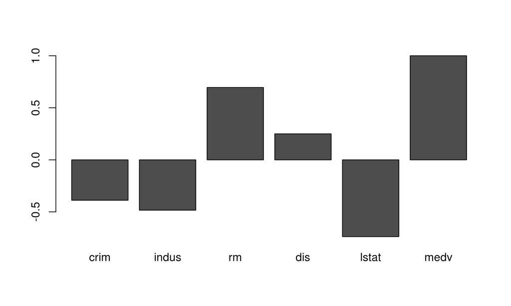

```r
barplot(cor(Boston$medv,Boston))
```

長條圖 barplot()

我們可以知道…

房價與 **該鎮平均房間數** 是 **正相關** ,與 **該鎮平均低收入戶比例** 是 **負相關**

房間數跟房價關係

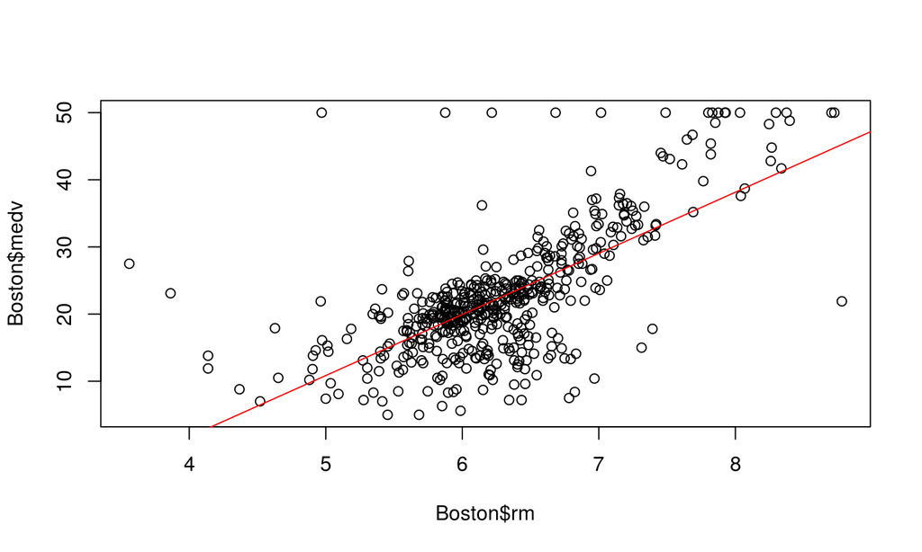

## 小練習 房間數與房價的關係

參考程式碼

```r
plot(Boston$rm,Boston$medv)
#x軸為房間數 y軸為房價
LM=lm(Boston$medv~Boston$rm)
#找出線性關係
abline(LM,col=2)
#畫出圖
```

畫圖 plot(x,y)  
線性模型(二元一次方程式,線性迴歸….) lm(y~x)  
在plot上加直線  
abline(x,col=)

現在我們知道

- 相關性 cor() -> 房價跟房間數正相關,低收入戶多寡負相關
- plot(), barplot() -> 我們還會畫圖

都能出國買房,買地  
要買就是要買最好的 最貴的

## 我要怎定義豪宅

找出前 5% (10%) 的房價

```r
quantile(Boston$medv, probs = c(0.95, 0.9))
```

```
##  95%  90%
## 43.4 34.8
```

百分位數點 quantile(x, probs=)

房價分布圖

- 使用 `hist` 做出房價的柱狀圖。

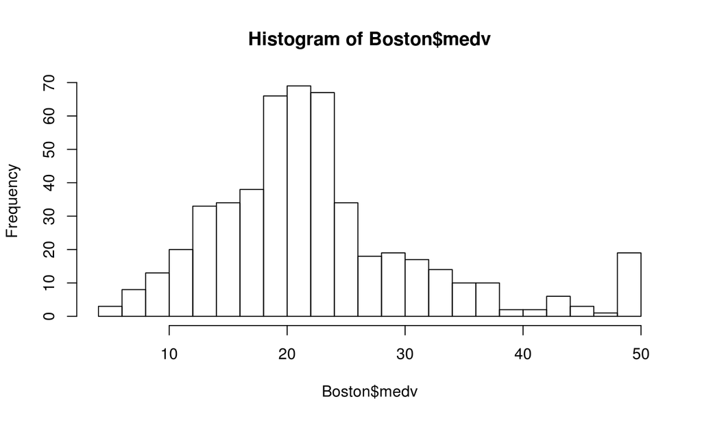

```r
hist(Boston$medv,breaks=20)
```

柱狀圖 hist(x,breaks= ) breaks:分成幾類

房價分布圖

- 使用 `abline` 標示出剛剛計算的前 5% 高的房價位置。

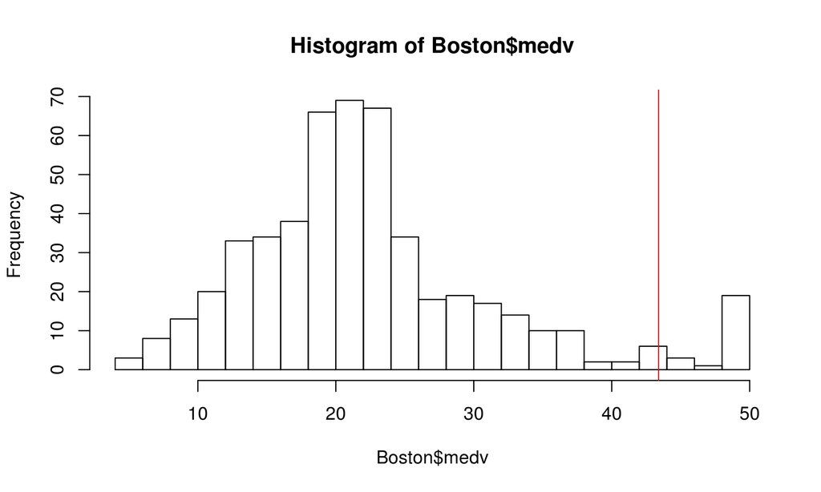

```r
hist(Boston$medv, breaks = 20)
abline(v = 43.4, col="red")
```

柱狀圖 hist(x,breaks= ) breaks:分成幾類

在plot上加直線 abline(x,col=)

高房價與其他是否有差異

- 前 5% 的房子的各項平均與其他房子是否有差異?
- 用 R 簡單計算來看看!

平均-高房價與其他是否有差異

- 使用 `subset` 做分群。

```r
MEDVhight = subset(Boston,Boston$medv>=43.4)
MEDVOther = subset(Boston,Boston$medv< 43.4)
# MEDVhight 為房價高的資料
# MEDVOther 其他資料
```

選取資料 subset(x,condition)

平均-高房價與其他是否有差異

- 使用 `colMeans` 計算各欄位平均。

```r
colMeans(MEDVhight)
```

```
##      crim     indus        rm       dis     lstat      medv
##  1.749602  8.934231  7.630885  3.127508  4.154615 48.453846
```

```r
colMeans(MEDVOther)
```

```
##      crim     indus        rm       dis     lstat      medv
##  3.714486 11.256083  6.211712  3.831201 13.113396 21.128750
```

欄平均 colMeans()

- 使用 `rbind` 合併資料表。

```r
rbind(colMeans(MEDVhight),colMeans(MEDVOther))
```

```
##          crim     indus       rm      dis     lstat     medv
## [1,] 1.749602  8.934231 7.630885 3.127508  4.154615 48.45385
## [2,] 3.714486 11.256083 6.211712 3.831201 13.113396 21.12875
```

高房價的鎮 犯罪率較低 商業區較少 住宅區比例高

Row Bind  
rbind(row1,row2)

我們現在知道～～

1. 平均數 rbind->高房價的鎮 犯罪率較低 商業區較少 住宅區比例高
2. 相關性 -> 房價跟房間數正相關,低收入戶多寡負相關

我們想更了解 低收入戶多寡跟房價的關係

```r
View(Boston)
```

## 高房價的鎮 該鎮低收入戶多寡

嘗試將低收入戶分類

[Show]

```r
Boston2=Boston
Boston2$Income=cut(Boston2$lstat,breaks=3)
#將低收入戶比例分成三類別
View(Boston2)
```

也可以用文字標記

H: 該鎮低收入戶比例 1.69% ~ 13.8%  
M: 該鎮低收入戶比例 13.8% ~ 25.9%  
L: 該鎮低收入戶比例 25.9% ~ 38%

[Show]

```r
Boston2$Income= cut(Boston2$lstat,breaks=3,labels=c("H","M","L"))
```

我可以計算有多少"H"嗎?

H: 該鎮低收入戶比例 1.69% ~ 13.8%  
M: 該鎮低收入戶比例 13.8% ~ 25.9%  
L: 該鎮低收入戶比例 25.9% ~ 38%

[Show]

```r
table(Boston2$Income)
```

```
##
##   H   M   L
## 313 162  31
```

各欄位加總 table()

我們現在知道～～

1. 平均數 rbind->高房價的鎮 犯罪率較低 商業區較少 住宅區比例高
2. 相關性 -> 房價跟房間數正相關,低收入戶多寡負相關

Let's Play Swirl

Section 3

## 我們來回顧剛剛研究的dataset

```r
str(Boston2)
```

```
## 'data.frame':    506 obs. of  7 variables:
##  $ crim  : num  0.00632 0.02731 0.02729 0.03237 0.06905 ...
##  $ indus : num  2.31 7.07 7.07 2.18 2.18 2.18 7.87 7.87 7.87 7.87 ...
##  $ rm    : num  6.58 6.42 7.18 7 7.15 ...
##  $ dis   : num  4.09 4.97 4.97 6.06 6.06 ...
##  $ lstat : num  4.98 9.14 4.03 2.94 5.33 ...
##  $ medv  : num  24 21.6 34.7 33.4 36.2 28.7 22.9 27.1 16.5 18.9 ...
##  $ Income: Factor w/ 3 levels "H","M","L": 1 1 1 1 1 1 1 2 3 2 ...
```

## R 與資料測量尺度

統計上資料測量的尺度分為以下幾種:

- 名目資料(nomial)
- 順序資料(ordinal)
- 區間資料(interval)
- 比例資料(ratio)

## 名目資料

- 數值只用於記號，**"值"**毫無意義的數據
  - 性別
  - 國家/班級

| 男 | 女 |
| --- | --- |
| 0 | 1 |

| 男 | 女 |
| --- | --- |
| 1 | 2 |

## 順序資料

- 數值有順序關係，但是差距沒有意義
  - 名次
  - 排序表

第一名的成績一定比第二名好, 但不代表第一名比第二名好兩倍

## 區間資料

- 有差距的概念，沒有倍數的概念。
- 數值有1的概念，沒有0的概念。可加減。
  - 溫度
  - 時間

## 比值資料

- 同時有差距和倍數的概念。
- 可加減乘除。
  - 使用者人數
  - 營收

| 資料衡量尺度 | 變數形態 | 特性 | 範例 |
| --- | --- | --- | --- |
| 名目資料 | 質性 | 類別 | 性別、縣市、國家 |
| 順序資料 | 質性 | 優先順序 | 名次 |
| 區間資料 | 量性 | 大小距離 | 溫度、時間 |
| 比例資料 | 量性 | 比值 | 營收、GDP |

## R 的基本資料結構

R 的基本資料結構 與統計測量尺度有密切的關係

R 的基本資料結構與統計測量尺度對應關係

| 測量尺度 | 變數形態 | 資料結構 |
| --- | --- | --- |
| 名目資料 | 質性 | Factor |
| 順序資料 | 質性 | Factor |
| 區間資料 | 量性 | Vector |
| 比例資料 | 量性 | Vector |

## Vector in R

請你先試打  
x=1  
再試打  
x=1,2

- 可以使用 `c` 這個內建函數建立向量

```r
x = c(1, 2)
```

範例: 12月份

```r
Month1=c(1,2,3,4,5,6,7,8,9,10,11,12)
Month2=1:12 # 建立連續向量的簡易寫法
```

練習一下

- 用剛剛學會的 `c` 來建立兩個向量, `taipei_tem` 跟 `hengchun_tem` 紀錄兩地氣溫。

台北恆春每月平均溫度

| 月份 | 1 | 2 | 3 | 4 | 5 | 6 | 7 | 8 | 9 | 10 | 11 | 12 |
| --- | --- | --- | --- | --- | --- | --- | --- | --- | --- | --- | --- | --- |
| 台北 | 16.1 | 16.5 | 18.5 | 21.9 | 25.2 | 27.7 | 29.6 | 29.2 | 27.4 | 24.5 | 21.5 | 17.9 |
| 恆春 | 20.7 | 21.4 | 23.2 | 25.2 | 27.0 | 27.9 | 28.4 | 28.1 | 27.4 | 26.3 | 24.3 | 21.7 |

## 練習一下

```r
TaipeiTem=c(16.1,16.5,18.5 ,  21.9 ,    25.2 ,  27.7 ,  29.6 ,  29.2,27.4,24.5 ,    21.5 ,  17.9)
HengchunTem=c(20.7 , 21.4 , 23.2 ,  25.2 ,  27.0 ,  27.9 ,  28.4 ,  28.1 ,  27.4 ,  26.3 ,  24.3 ,  21.7)
```

加上月份名

```r
names(TaipeiTem) = Month1

names(HengchunTem) = Month2
TaipeiTem
HengchunTem
```

```
##    1    2    3    4    5    6    7    8    9   10   11   12
## 16.1 16.5 18.5 21.9 25.2 27.7 29.6 29.2 27.4 24.5 21.5 17.9
##    1    2    3    4    5    6    7    8    9   10   11   12
## 20.7 21.4 23.2 25.2 27.0 27.9 28.4 28.1 27.4 26.3 24.3 21.7
```

## Element-by-Element Operation

```r
c(1, 2, 3) + c(3, 2, 1)
```

```
## [1] 4 4 4
```

## Element-by-Element Operation

```r
c(1, 2, 3) + 1
```

```
## [1] 2 3 4
```

## Element-by-Element Operation

```r
c(1, 2, 3) + 1
```

```
## [1] 2 3 4
```

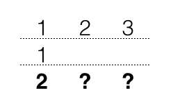

## Element-by-Element Operation

```r
c(1, 2, 3) + 1
```

```
## [1] 2 3 4
```

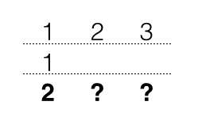

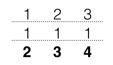

## 猜猜看

```r
guess <- c(1:10) + c(2, 4)
```

- `guess` 會是多少呢?

```r
guess
```

```
##  [1]  3  6  5  8  7 10  9 12 11 14
```

## 練習看看

```r
1:3 * 2
```

```
## [1] 2 4 6
```

## 向量的同質性

Character > Numeric > Logical

```r
x <- c(1, 2, "3")
x
```

```
## [1] "1" "2" "3"
```

- 向量中的所有元素都必須是同一種型別。

R 的基本資料結構與剛剛所提到的測量尺度有密切的關係

| 測量尺度 | 變數形態 | 資料結構 |
| --- | --- | --- |
| 名目資料 | 質性 | Factor |
| 順序資料 | 質性 | Factor |
| 區間資料 | 量性 | Vector |
| 比例資料 | 量性 | Vector |

## Factor(常用於處理質性)

如何處理名目變數?

```r
x <- c("F","M","F","F")
x
```

```
## [1] "F" "M" "F" "F"
```

```r
x <- factor(c("F","M","F","F"), levels=c("F","M"))
x
```

```
## [1] F M F F
## Levels: F M
```

```r
as.integer(x)
```

```
## [1] 1 2 1 1
```

```r
levels(x)
```

```
## [1] "F" "M"
```

```r
x <- factor(c("F","M","F","F"), levels=c("F"))
x
```

```
## [1] F    <NA> F    F
## Levels: F
```

## 如何處理順序資料?

農業社會 男尊女卑

```r
#農業社會 男尊女卑
Argri <- factor(c("F","M","F","F"),order=TRUE,levels=c("F","M"))
```

阿美族 女尊男卑

```r
#阿美族 女尊男卑
Amis <- factor(c("F","M","F","F"),order=FALSE,levels=c("F","M"))

#應該要用
Amis <- factor(c("F","M","F","F"),order=TRUE,levels=c("M","F"))
```

舉一個認真的例子 - 班上一號到六號分別拿到A,B,C的級別

```r
rank=factor(c("C","A","B","B","C","C"),order=TRUE,level=c("C","B","A"))
rank
```

```
## [1] C A B B C C
## Levels: C < B < A
```

```r
rank[1]<rank[2]
```

```
## [1] TRUE
```

Recap

同質性資料

| 資料衡量尺度 | 變數形態 | 資料結構 | 特性 | 範例 |
| --- | --- | --- | --- | --- |
| 名目資料 | 質性 | Factor | 類別 | 性別、縣市、國家 |
| 順序資料 | 質性 | Factor | 優先順序 | 名次 |
| 區間資料 | 量性 | Vector | 大小距離 | 溫度、時間 |
| 比例資料 | 量性 | Vector | 比值 | 營收、GDP |

## Character

- 最廣泛的資料結構，可用於處理文字相關的工作，如：設定圖片的標題
- 輸入的時候利用`"`或`'`來包覆要輸入的文字

常用的Character處理函數

字串的剪接：`paste`

```r
x <- "abc";y <- "dbbbe"
paste(x, y, sep=",")
```

```
## [1] "abc,dbbbe"
```

字串的切割：`strsplit`

```r
strsplit(x, "b")
```

```
## [[1]]
## [1] "a" "c"
```

截取子字串：`substring`

```r
name1<-"郭雪芙"
substring(name1, 1, 1)
```

```
## [1] "郭"
```

## 來個小練習 先從向量開始

輸入蔡依林的基本資料:  
age:34  
height:158  
weight:40

```r
Jolin = c(age=34,height=158,weight=40)
Jolin
```

```
##    age height weight
##     34    158     40
```

請你幫我加上Jolin 是台北人,女性的資料  
Location:"Taipei"  
Gender:"F"

```r
Jolin = c(age=34,height=158,weight=40,Location="Taipei",Gender="F")
Jolin
```

```
##      age   height   weight Location   Gender
##     "34"    "158"     "40" "Taipei"      "F"
```

有注意到資料都變成 字串(character)

## R 如何處理異質性資料?

### 異質性資料 List

```r
x<-list(1,2,"3")
```

剛才的Jolin資料  
全部都是字串("")

```r
Jolin = c(age=34,height=158,weight=40,Location="Taipei",Gender="F")
Jolin
```

```
##      age   height   weight Location   Gender
##     "34"    "158"     "40" "Taipei"      "F"
```

## 小練習 List

請問蔡依林的基本資料,要怎儲存成異質性資料?

答案

```r
#答案
Jolin = list(age=34,height=158,weight=40,Location="Taipei",Gender="F")
Jolin
```

```
## $age
## [1] 34
##
## $height
## [1] 158
##
## $weight
## [1] 40
##
## $Location
## [1] "Taipei"
##
## $Gender
## [1] "F"
```

## 異質性資料 dataframe

View(Boston)

DataFrame呈現

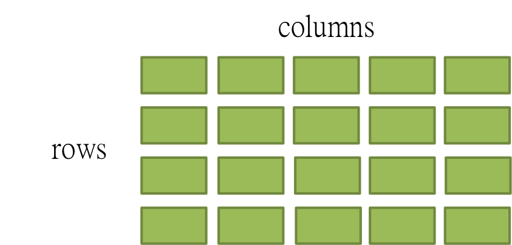

DataFrame Row的概念

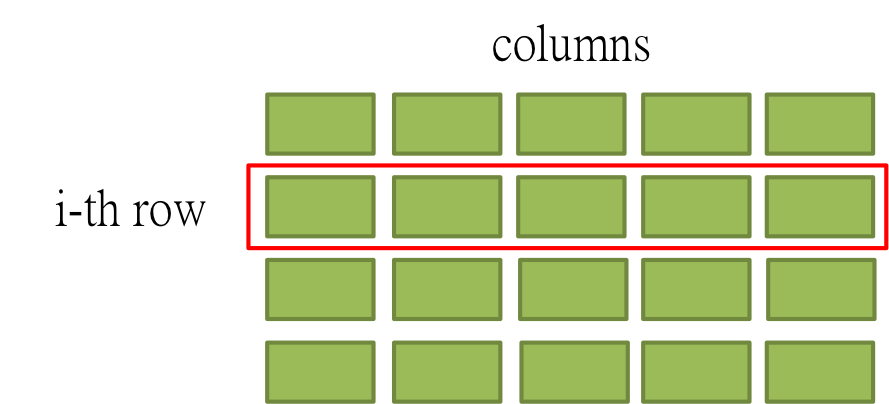

```r
View(Boston)
Boston[1,]
```

```
##      crim indus    rm  dis lstat medv
## 1 0.00632  2.31 6.575 4.09  4.98   24
```

DataFrame Column的概念

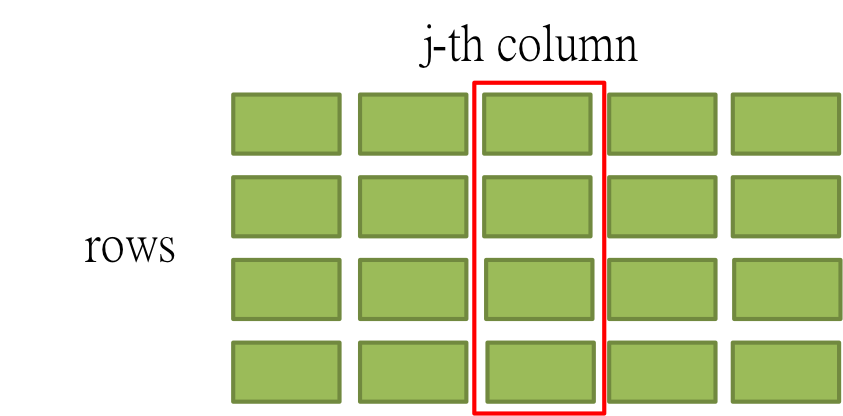

```r
View(Boston)
Boston[,1]
```

[output not shown]

[output cut: 58 more lines]

寫函數 (x,)  
選取 [row,column]

Ways to add a column

Boston$Income<-  
Boston[["Income"]]<-

Ways to remove the column

Boston$Income<-NULL  
Boston[["Income"]]<-NULL

rbind

```r
Serial=c(1,2,3)
RBasicTeacher=c("Dboy", "Ning", "Noah")
RBasicRbind=rbind(Serial,RBasicTeacher)
```

cbind

```r
Serial=c(1,2,3)
RBasicTeacher=c("Dboy", "Ning", "Noah")
RBasicCbind=cbind(Serial,RBasicTeacher)
RBasic=cbind(c(1,2,3),c("Dboy", "Ning", "Noha"))
```

## summary 指令

- 根據資料形態的不同，函數的輸出結果也會不同

Factor

```r
factor_example=factor(c("A", "B", "A"))
summary(factor_example)
```

```
## A B
## 2 1
```

Character

```r
character_example=c("a","b","c")
summary(character_example)
```

```
##    Length     Class      Mode
##         3 character character
```

List

```r
list_example <- list(1, 2.0, "3")
summary(list_example)
```

```
##      Length Class  Mode
## [1,] 1      -none- numeric
## [2,] 1      -none- numeric
## [3,] 1      -none- character
```

DataFrame

```r
summary(Boston2)
```

```
##       crim              indus             rm             dis
##  Min.   : 0.00632   Min.   : 0.46   Min.   :3.561   Min.   : 1.130
##  1st Qu.: 0.08204   1st Qu.: 5.19   1st Qu.:5.886   1st Qu.: 2.100
##  Median : 0.25651   Median : 9.69   Median :6.208   Median : 3.207
##  Mean   : 3.61352   Mean   :11.14   Mean   :6.285   Mean   : 3.795
##  3rd Qu.: 3.67708   3rd Qu.:18.10   3rd Qu.:6.623   3rd Qu.: 5.188
##  Max.   :88.97620   Max.   :27.74   Max.   :8.780   Max.   :12.127
##      lstat            medv       Income
##  Min.   : 1.73   Min.   : 5.00   H:313
##  1st Qu.: 6.95   1st Qu.:17.02   M:162
##  Median :11.36   Median :21.20   L: 31
##  Mean   :12.65   Mean   :22.53
##  3rd Qu.:16.95   3rd Qu.:25.00
##  Max.   :37.97   Max.   :50.00
```

## 資料的選取

## 向量的選取

坐標

```r
x <- 1:5
x[2:3]
```

```
## [1] 2 3
```

布林

```r
x <- 1:5
x > 3
```

```
## [1] FALSE FALSE FALSE  TRUE  TRUE
```

```r
x[x > 3]
```

```
## [1] 4 5
```

## 小挑戰選取台北恆春天氣資料

先印出台北跟恆春每個月平均溫度

```r
TaipeiTem
```

```
##    1    2    3    4    5    6    7    8    9   10   11   12
## 16.1 16.5 18.5 21.9 25.2 27.7 29.6 29.2 27.4 24.5 21.5 17.9
```

```r
HengchunTem
```

```
##    1    2    3    4    5    6    7    8    9   10   11   12
## 20.7 21.4 23.2 25.2 27.0 27.9 28.4 28.1 27.4 26.3 24.3 21.7
```

分別選取出兩地溫度>20度的月份

- > <

```r
TaipeiTem>20
```

```
##     1     2     3     4     5     6     7     8     9    10    11    12
## FALSE FALSE FALSE  TRUE  TRUE  TRUE  TRUE  TRUE  TRUE  TRUE  TRUE FALSE
```

```r
TaipeiHotMonths = TaipeiTem[TaipeiTem>20]
```

- True & False

```r
SelectMonth= HengchunTem>20
HengchunHotMonths = HengchunTem[SelectMonth==TRUE]
```

找出夏天(七八九月)平均溫度

```r
 TaipeiTem[7:9]
```

```
##    7    8    9
## 29.6 29.2 27.4
```

```r
mean(TaipeiTem[7:9])
```

```
## [1] 28.73333
```

```r
HengchunTem[7:9]
```

```
##    7    8    9
## 28.4 28.1 27.4
```

```r
mean(HengchunTem[7:9])
```

```
## [1] 27.96667
```

找出冬天(十二,一,二月)平均溫度

```r
# TaipeiTem[1,2,12]
mean(TaipeiTem[c(1,2,12)])
```

```
## [1] 16.83333
```

```r
mean(HengchunTem[c(1,2,12)])
```

```
## [1] 21.26667
```

表格的選取

```r
TemTable=rbind(TaipeiTem,HengchunTem)
TemTable
```

```
##                1    2    3    4    5    6    7    8    9   10   11   12
## TaipeiTem   16.1 16.5 18.5 21.9 25.2 27.7 29.6 29.2 27.4 24.5 21.5 17.9
## HengchunTem 20.7 21.4 23.2 25.2 27.0 27.9 28.4 28.1 27.4 26.3 24.3 21.7
```

```r
#選取台北二月的溫度
TemTable[1,2]
```

```
## [1] 16.5
```

```r
#選取二月的溫度
TemTable[,2]
```

```
##   TaipeiTem HengchunTem
##        16.5        21.4
```

```r
TemTable[1,]
```

```
##    1    2    3    4    5    6    7    8    9   10   11   12
## 16.1 16.5 18.5 21.9 25.2 27.7 29.6 29.2 27.4 24.5 21.5 17.9
```

欄的選取

```r
head(Boston)
```

```
##      crim indus    rm    dis lstat medv
## 1 0.00632  2.31 6.575 4.0900  4.98 24.0
## 2 0.02731  7.07 6.421 4.9671  9.14 21.6
## 3 0.02729  7.07 7.185 4.9671  4.03 34.7
## 4 0.03237  2.18 6.998 6.0622  2.94 33.4
## 5 0.06905  2.18 7.147 6.0622  5.33 36.2
## 6 0.02985  2.18 6.430 6.0622  5.21 28.7
```

```r
head(Boston[["crim"]]) # head(Boston$crim)
```

```
## [1] 0.00632 0.02731 0.02729 0.03237 0.06905 0.02985
```

## 轉換資料結構

`as`

- `as.character`
- `as.logical`
- `as.integer`
- `as.numeric`

```r
as.numeric("2")
```

```
## [1] 2
```

```r
as.integer("a")
```

```
## [1] NA
```

```r
x <- c(1, 2, 3, 2, 3, 2, 1)
as.character(x) # 字串
```

```
## [1] "1" "2" "3" "2" "3" "2" "1"
```

```r
factor(x)
```

```
## [1] 1 2 3 2 3 2 1
## Levels: 1 2 3
```

直接轉換

```r
x <- c("1", "2", "3", "2", "a")
as.numeric(x)
```

```
## [1]  1  2  3  2 NA
```

- `NA`代表Not available，代表著**missing value**

## 補充資料

- [Swirl Courses](https://github.com/swirldev/swirl_courses)
- [Introduction to R](https://www.datacamp.com/courses/free-introduction-to-r) (around 4 hours)
- [Cookbook for R](http://www.cookbook-r.com/)

## Acknowlege

- Wush

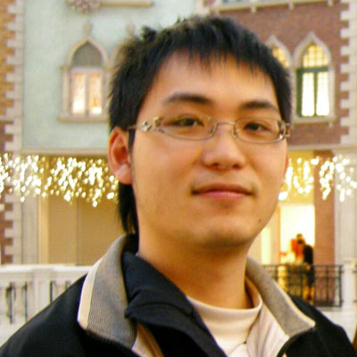

- 智程

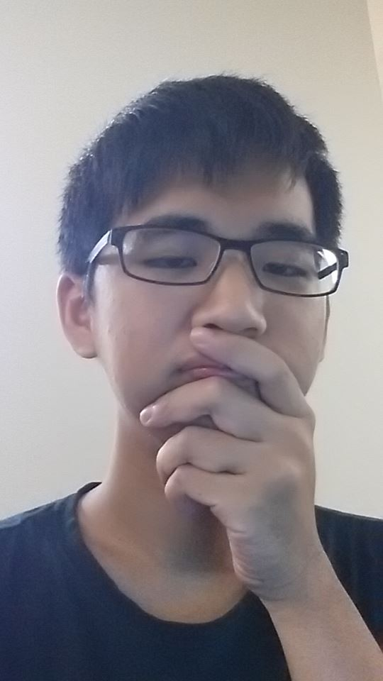

- Dboy

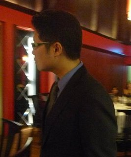

Let's Play Swirl

**Section 4**